# Machine Learning Project 2

**Madison Chester and Krisha Vekaria**

Here we are importing everything we need for analysis.

```python
import pandas as pd
from matplotlib import pyplot as plt
import numpy as np
import seaborn as sns
from sklearn.model_selection import train_test_split, GridSearchCV
from sklearn.preprocessing import StandardScaler
from sklearn.linear_model import Ridge, LogisticRegression
from sklearn.pipeline import make_pipeline
from sklearn.metrics import mean_squared_error, r2_score
from sklearn.linear_model import RidgeCV
from sklearn.metrics import accuracy_score
```

Problem: We are trying to predict whether or not a patient has diabetes based on various diagnostic measures.

Here we are reading in the dataset, which can be found at https://www.kaggle.com/datasets/uciml/pima-indians-diabetes-database. The data is from the National Institute of Diabetes and Digestive and Kidney Diseases, and all patients here are females at least 21 years old of Pima Indian heritage. We will be using linear regression with regularization, logistic regression, and random forest to predict the onset of diabetes. Variables in the dataset include pregnancies, glucose, blood pressure, skin thickness, insuline, BMI, diabetes pedigree funtcion, age, and finally outcome. In our analysis, we will be using all variables in the dataset to predict outcome.

```python
df = pd.read_csv('diabetes.csv')
df.head()
```

|  | Pregnancies | Glucose | BloodPressure | SkinThickness | Insulin | BMI | DiabetesPedigreeFunction | Age | Outcome |
| --- | --- | --- | --- | --- | --- | --- | --- | --- | --- |
| 0 | 6 | 148 | 72 | 35 | 0 | 33.6 | 0.627 | 50 | 1 |
| 1 | 1 | 85 | 66 | 29 | 0 | 26.6 | 0.351 | 31 | 0 |
| 2 | 8 | 183 | 64 | 0 | 0 | 23.3 | 0.672 | 32 | 1 |
| 3 | 1 | 89 | 66 | 23 | 94 | 28.1 | 0.167 | 21 | 0 |
| 4 | 0 | 137 | 40 | 35 | 168 | 43.1 | 2.288 | 33 | 1 |

```python
df.shape
```

```
(768, 9)
```

```python
df.describe()
```

|  | Pregnancies | Glucose | BloodPressure | SkinThickness | Insulin | BMI | DiabetesPedigreeFunction | Age | Outcome |
| --- | --- | --- | --- | --- | --- | --- | --- | --- | --- |
| count | 768.000000 | 768.000000 | 768.000000 | 768.000000 | 768.000000 | 768.000000 | 768.000000 | 768.000000 | 768.000000 |
| mean | 3.845052 | 120.894531 | 69.105469 | 20.536458 | 79.799479 | 31.992578 | 0.471876 | 33.240885 | 0.348958 |
| std | 3.369578 | 31.972618 | 19.355807 | 15.952218 | 115.244002 | 7.884160 | 0.331329 | 11.760232 | 0.476951 |
| min | 0.000000 | 0.000000 | 0.000000 | 0.000000 | 0.000000 | 0.000000 | 0.078000 | 21.000000 | 0.000000 |
| 25% | 1.000000 | 99.000000 | 62.000000 | 0.000000 | 0.000000 | 27.300000 | 0.243750 | 24.000000 | 0.000000 |
| 50% | 3.000000 | 117.000000 | 72.000000 | 23.000000 | 30.500000 | 32.000000 | 0.372500 | 29.000000 | 0.000000 |
| 75% | 6.000000 | 140.250000 | 80.000000 | 32.000000 | 127.250000 | 36.600000 | 0.626250 | 41.000000 | 1.000000 |
| max | 17.000000 | 199.000000 | 122.000000 | 99.000000 | 846.000000 | 67.100000 | 2.420000 | 81.000000 | 1.000000 |

Here, we are just checking to make sure there is no missing data that needs to be omitted before analysis.

```python
df.isnull().sum()
```

```
Pregnancies                 0
Glucose                     0
BloodPressure               0
SkinThickness               0
Insulin                     0
BMI                         0
DiabetesPedigreeFunction    0
Age                         0
Outcome                     0
dtype: int64
```

Here we are plotting the histogram of each independent variable to get an idea of their range and distribution.

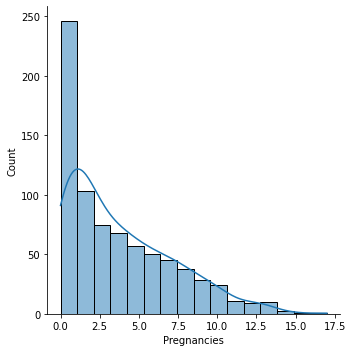

```python
sns.displot(df, x="Pregnancies", kde=True)
```

The distribution of pregnancies is unimodal and skewed right.

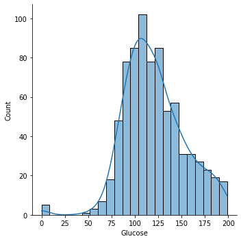

```python
sns.displot(df, x="Glucose", kde=True)
```

The distribution of glucose is unimodal and relatively normal.

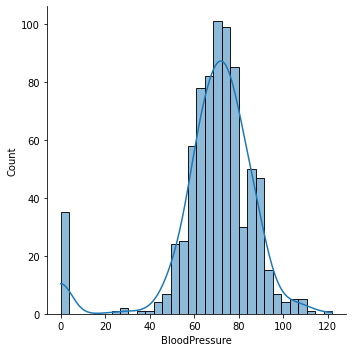

```python
sns.displot(df, x="BloodPressure", kde=True)
```

The distribution of blood pressure is bimodal due to a spike at 0, which could be a possible outlier or measurement inaccuracy but is relatively normal in shape otherwise.

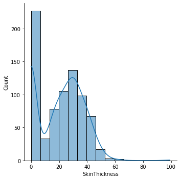

```python
sns.displot(df, x="SkinThickness", kde=True)
```

The distribution of skin thickness is bimodal with a large spike at 0 and around 30, but when excluding the spike at 0, it has a relatively normal shape centered around 30.

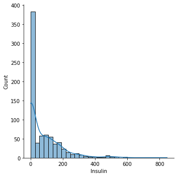

```python
sns.displot(df, x="Insulin", kde=True)
```

The distribution of insulin is unimodal and has a large spike at 0 and is skewed to the right afterwards.

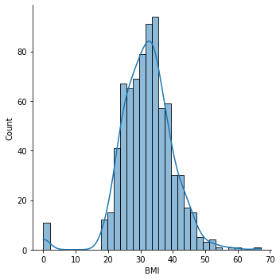

```python
sns.displot(df, x="BMI", kde=True)
```

The distribution of BMI is relatively normal and unimodal, but has a small outlier at 0, which may be due to measurement inaccuracy.

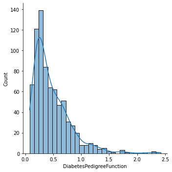

```python
sns.displot(df, x="DiabetesPedigreeFunction", kde=True)
```

The diabetes pedigree function is unimodal and skewed right.

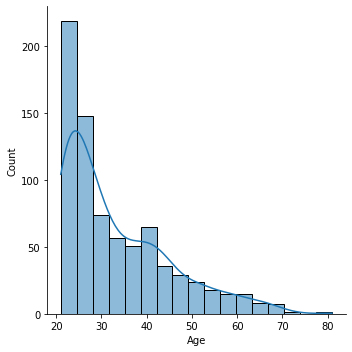

```python
sns.displot(df, x="Age", kde=True)
```

The distribution of age is also unimodal and skewed right, with the largest spike occuring in the 20-30 age range.

Next, we generate a correlation matrix. Here, Age and Pregnancies are decently positively correlated, as are Glucose and Outcome. However, this visualization was created with the intention of guarding against multicollinearity in our model. Our positive correlations are not strong enough though, to make removing a column to avoid mulitcollinearity necessary.

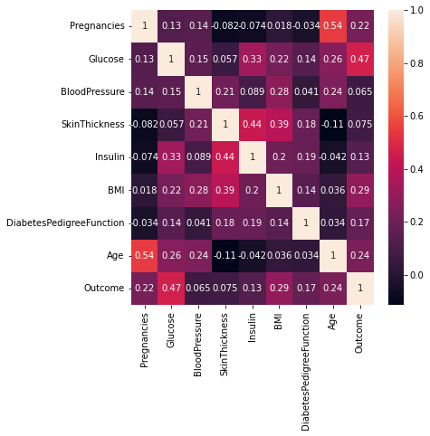

```python
plt.figure(figsize=(6,6))
corr = df.corr()
sns.heatmap(corr, annot=True)
plt.show()
```

Here, we are creating pairplots to visualize how each variable relates to outcome individually in order to conceptualize how they will all work together in our model. Creating the pairplots also allows us to visualize the pairwise relationships between all variables in our dataset.

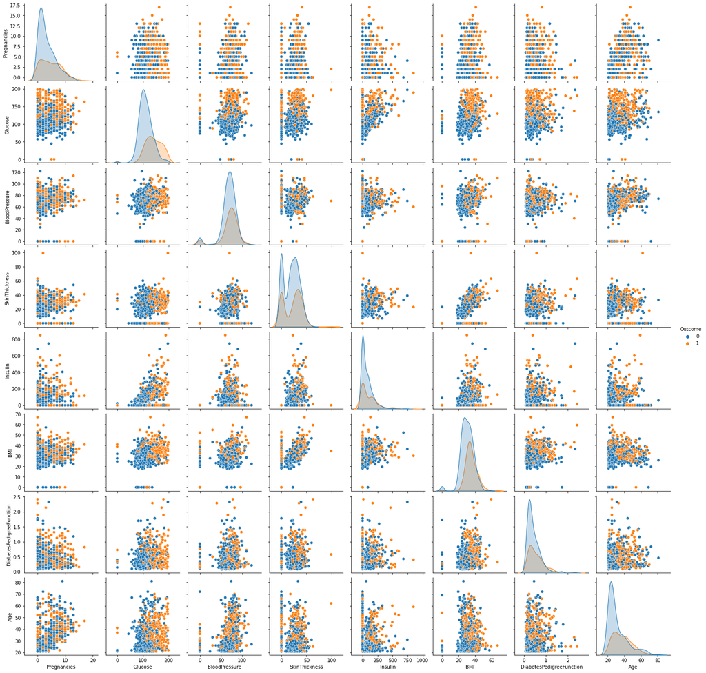

```python
sns.pairplot(df, hue="Outcome")
plt.show()
```

Here, we extract X and Y from our dataset. X consists of all variables in the dataset excluding outcome, and Y consists of only outcome. The outcome variable is binary, with outcome 0 indicating the absence of diabetes, and outcome 1 indicating the presence of diabetes.

```python
# extract X and Y
X = df.drop(['Outcome'], axis=1)
y = df['Outcome']
```

Here, we are splitting the data between training (70%) and testing (30%).

```python
 X_train, X_test, y_train, y_test = train_test_split(X, y, test_size=0.3, random_state=42)
```

The first method we are using to predict outcome is ridge regression. Here, we are using the ridge algorithm to train the model.

```python
pipeline = make_pipeline(StandardScaler(), Ridge(alpha=1.0))
pipeline.fit(X_train, y_train)
```

```
Pipeline(steps=[('standardscaler', StandardScaler()), ('ridge', Ridge())])
```

Here, we are calculating the predicted values for the training and testing dataset.

```python
y_train_pred = pipeline.predict(X_train)
y_test_pred = pipeline.predict(X_test)
```

```python
print('MSE train: %.3f, test: %.3f' % (mean_squared_error(y_train, y_train_pred), mean_squared_error(y_test, y_test_pred)))
```

```
MSE train: 0.155, test: 0.176
```

Finally, to understand waht percentage of variance is accounted for in our models, we calcualted R^2. 32.1% of the variance in outcomes of the training data can be explained by all other variables in the dataset. 22.3% of the variance in outcomes of the testing data can be explained by all other variables in the dataset.

```python
# R squared
print('R^2 train: %.3f, test: %.3f' % (r2_score(y_train, y_train_pred), r2_score(y_test, y_test_pred)))
```

```
R^2 train: 0.321, test: 0.223
```

Finally, in order to benchmark this model against another, it is important to calculate accuracy of the model. The model correctly predicted 73.16% of the outcomes.

```python
y_test_pred_binary = [0 if i < 0.5 else 1 for i in y_test_pred]
accuracy = accuracy_score(y_test, y_test_pred_binary)
print(f'Accuracy: {accuracy*100:.2f}%')
```

```
Accuracy: 73.16%
```

Lastly, we performed cross-validation with three different alpha values (1, 1000, 1000000).

```python
alphas=[1, 1e3, 1e6]
regressor = RidgeCV(alphas, store_cv_values=True)
regressor.fit(X_train, y_train)
cv_mse = np.mean(regressor.cv_values_, axis=0)
print(alphas)
print(cv_mse)
```

```
[1, 1000.0, 1000000.0]
[0.16069309 0.16028208 0.19575537]
```

We then determined the best alpha.

```python
print(regressor.alpha_)
```

```
1000.0
```

We then predicted and plotted y for the test dataset.

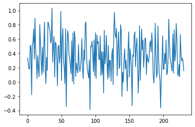

```python
predict_y = regressor.predict(X_test)
plt.plot(predict_y)
```

Now, we are using logistic regression to train the model using the traning and testing sets that were previously created.

```python
lr = LogisticRegression()
lr.fit(X_train, y_train)
```

```
LogisticRegression()
```

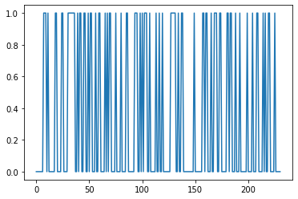

```python
y_pred_lr = lr.predict(X_test)
plt.plot(y_pred_lr)
```

We then calculated the accuracy of the logistic regression model. The model correctly predicted 74.03% of the outcomes.

```python
lr_accuracy = accuracy_score(y_test, y_pred_lr)
print(f'Logistic Regression Accuracy: {lr_accuracy*100:.2f}%')
```

```
Logistic Regression Accuracy: 74.03%
```

Finally, we created a visualization that compares the accuracy of the classification models.

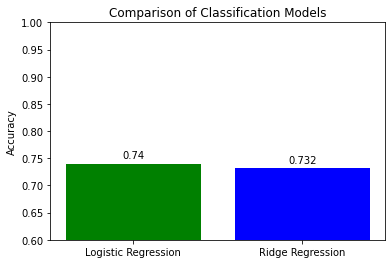

```python
models = ["Logistic Regression", "Ridge Regression"]
accuracies = [lr_accuracy, accuracy]
colors = ['g', 'b']
plt.bar(models, accuracies, color=colors)
plt.ylim(0.6, 1)
plt.ylabel("Accuracy")
plt.title("Comparison of Classification Models")
for i, v in enumerate(accuracies):
    plt.text(i, v + 0.01, str(round(v, 3)), ha='center')
plt.show()
```

Next and lastly, we will use a random forest to predict the outcome.

We define the labels and save column names for future use.

```python
# Use numpy to convert to arrays
import numpy as np
# Labels are the values we want to predict
labels = np.array(df['Outcome'])
# Remove the labels from the features
# axis 1 refers to the columns
features = df.drop('Outcome', axis = 1)
# Saving feature names for later use
feature_list = list(features.columns)
# Convert to numpy array
features = np.array(features)
```

Next, we use sci-kit learn to split the data into training (70%) and testing (30%).

```python
# Using Skicit-learn to split data into training and testing sets
from sklearn.model_selection import train_test_split
# Split the data into training and testing sets
train_features, test_features, train_labels, test_labels = train_test_split(features, labels, test_size = 0.30, random_state = 42)
```

Just to be sure this was done correctly, we print the shape of the training and testing sets with all variables and simply the outcome variable.

```python
print('Training Features Shape:', train_features.shape)
print('Training Labels Shape:', train_labels.shape)
print('Testing Features Shape:', test_features.shape)
print('Testing Labels Shape:', test_labels.shape)
```

```
Training Features Shape: (537, 8)
Training Labels Shape: (537,)
Testing Features Shape: (231, 8)
Testing Labels Shape: (231,)
```

Next, we import, instantiate, and train the model.

```python
# Import the model we are using
from sklearn.ensemble import RandomForestRegressor
# Instantiate model with 1000 decision trees
rf = RandomForestRegressor(n_estimators = 1000, random_state = 42)
# Train the model on training data
rf.fit(train_features, train_labels);
```

Lastly, we use the trained model to predict the outcome variable for the testing set, and compute the mean absolute error as a measure of accuracy.

```python
# Use the forest's predict method on the test data
predictions = rf.predict(test_features)
# Calculate the absolute errors
errors = abs(predictions - test_labels)
# Print out the mean absolute error (mae)
print('Mean Absolute Error:', round(np.mean(errors), 2))
```

```
Mean Absolute Error: 0.32
```